# Project: The Movie Database

- Introduction
- Data Wrangling
- Exploratory Data Analysis
- Conclusions

## Introduction

> This report will investigate The Movie Database (TMDb) dataset. This dataset contains information of ~10,000 movies.

> Dataset includes the following properties:

```
        id, imdb_id, popularity, budget, revenue, original_title, cast, homepage, director, tagline, keywords,
        overview, runtime, genres, production_companies, release_date, vote_count, vote_average, release_year,
        budget_adj, revenue_adj
```

> This investigation will focus on the popularity of the various genres, directors, actors, and movie revenues.

> Over the course of this report the following questions will be explored:
> - What genres are most popular?
> - Which directors are associated with movies with high revenues?
> - Who are the most featured (popular) actors?

```python
# Import statements
import numpy as np
import pandas as pd
import matplotlib.pyplot as plt
import seaborn as sns
%matplotlib inline
```

# Data Wrangling

### General Properties:

```python
# Load data and output first few rows of data
df = pd.read_csv('tmdb-movies.csv')
df.head()
```

|  | id | imdb_id | popularity | budget | revenue | original_title | cast | homepage | director | tagline | ... | overview | runtime | genres | production_companies | release_date | vote_count | vote_average | release_year | budget_adj | revenue_adj |
| --- | --- | --- | --- | --- | --- | --- | --- | --- | --- | --- | --- | --- | --- | --- | --- | --- | --- | --- | --- | --- | --- |
| 0 | 135397 | tt0369610 | 32.985763 | 150000000 | 1513528810 | Jurassic World | Chris Pratt\|Bryce Dallas Howard\|Irrfan Khan\|Vi... | http://www.jurassicworld.com/ | Colin Trevorrow | The park is open. | ... | Twenty-two years after the events of Jurassic ... | 124 | Action\|Adventure\|Science Fiction\|Thriller | Universal Studios\|Amblin Entertainment\|Legenda... | 6/9/15 | 5562 | 6.5 | 2015 | 1.379999e+08 | 1.392446e+09 |
| 1 | 76341 | tt1392190 | 28.419936 | 150000000 | 378436354 | Mad Max: Fury Road | Tom Hardy\|Charlize Theron\|Hugh Keays-Byrne\|Nic... | http://www.madmaxmovie.com/ | George Miller | What a Lovely Day. | ... | An apocalyptic story set in the furthest reach... | 120 | Action\|Adventure\|Science Fiction\|Thriller | Village Roadshow Pictures\|Kennedy Miller Produ... | 5/13/15 | 6185 | 7.1 | 2015 | 1.379999e+08 | 3.481613e+08 |
| 2 | 262500 | tt2908446 | 13.112507 | 110000000 | 295238201 | Insurgent | Shailene Woodley\|Theo James\|Kate Winslet\|Ansel... | http://www.thedivergentseries.movie/#insurgent | Robert Schwentke | One Choice Can Destroy You | ... | Beatrice Prior must confront her inner demons ... | 119 | Adventure\|Science Fiction\|Thriller | Summit Entertainment\|Mandeville Films\|Red Wago... | 3/18/15 | 2480 | 6.3 | 2015 | 1.012000e+08 | 2.716190e+08 |
| 3 | 140607 | tt2488496 | 11.173104 | 200000000 | 2068178225 | Star Wars: The Force Awakens | Harrison Ford\|Mark Hamill\|Carrie Fisher\|Adam D... | http://www.starwars.com/films/star-wars-episod... | J.J. Abrams | Every generation has a story. | ... | Thirty years after defeating the Galactic Empi... | 136 | Action\|Adventure\|Science Fiction\|Fantasy | Lucasfilm\|Truenorth Productions\|Bad Robot | 12/15/15 | 5292 | 7.5 | 2015 | 1.839999e+08 | 1.902723e+09 |
| 4 | 168259 | tt2820852 | 9.335014 | 190000000 | 1506249360 | Furious 7 | Vin Diesel\|Paul Walker\|Jason Statham\|Michelle ... | http://www.furious7.com/ | James Wan | Vengeance Hits Home | ... | Deckard Shaw seeks revenge against Dominic Tor... | 137 | Action\|Crime\|Thriller | Universal Pictures\|Original Film\|Media Rights ... | 4/1/15 | 2947 | 7.3 | 2015 | 1.747999e+08 | 1.385749e+09 |

5 rows × 21 columns

```python
# Current size of the dataframe
df.shape
```

```
(10866, 21)
```

```python
# List the data types and discover with columns are missing data
df.info()
```

```
<class 'pandas.core.frame.DataFrame'>
RangeIndex: 10866 entries, 0 to 10865
Data columns (total 21 columns):
id                      10866 non-null int64
imdb_id                 10856 non-null object
popularity              10866 non-null float64
budget                  10866 non-null int64
revenue                 10866 non-null int64
original_title          10866 non-null object
cast                    10790 non-null object
homepage                2936 non-null object
director                10822 non-null object
tagline                 8042 non-null object
keywords                9373 non-null object
overview                10862 non-null object
runtime                 10866 non-null int64
genres                  10843 non-null object
production_companies    9836 non-null object
release_date            10866 non-null object
vote_count              10866 non-null int64
vote_average            10866 non-null float64
release_year            10866 non-null int64
budget_adj              10866 non-null float64
revenue_adj             10866 non-null float64
dtypes: float64(4), int64(6), object(11)
memory usage: 1.7+ MB
```

### There are several columns with missing data. With the scope of this analysis, some of these columns with missing data do not have any foreseen use. They will be removed for now.

```python
# Remove the columns not needed in this analysis
df.drop(['homepage', 'tagline', 'overview'], axis=1, inplace=True)
df.head()
```

|  | id | imdb_id | popularity | budget | revenue | original_title | cast | director | keywords | runtime | genres | production_companies | release_date | vote_count | vote_average | release_year | budget_adj | revenue_adj |
| --- | --- | --- | --- | --- | --- | --- | --- | --- | --- | --- | --- | --- | --- | --- | --- | --- | --- | --- |
| 0 | 135397 | tt0369610 | 32.985763 | 150000000 | 1513528810 | Jurassic World | Chris Pratt\|Bryce Dallas Howard\|Irrfan Khan\|Vi... | Colin Trevorrow | monster\|dna\|tyrannosaurus rex\|velociraptor\|island | 124 | Action\|Adventure\|Science Fiction\|Thriller | Universal Studios\|Amblin Entertainment\|Legenda... | 6/9/15 | 5562 | 6.5 | 2015 | 1.379999e+08 | 1.392446e+09 |
| 1 | 76341 | tt1392190 | 28.419936 | 150000000 | 378436354 | Mad Max: Fury Road | Tom Hardy\|Charlize Theron\|Hugh Keays-Byrne\|Nic... | George Miller | future\|chase\|post-apocalyptic\|dystopia\|australia | 120 | Action\|Adventure\|Science Fiction\|Thriller | Village Roadshow Pictures\|Kennedy Miller Produ... | 5/13/15 | 6185 | 7.1 | 2015 | 1.379999e+08 | 3.481613e+08 |
| 2 | 262500 | tt2908446 | 13.112507 | 110000000 | 295238201 | Insurgent | Shailene Woodley\|Theo James\|Kate Winslet\|Ansel... | Robert Schwentke | based on novel\|revolution\|dystopia\|sequel\|dyst... | 119 | Adventure\|Science Fiction\|Thriller | Summit Entertainment\|Mandeville Films\|Red Wago... | 3/18/15 | 2480 | 6.3 | 2015 | 1.012000e+08 | 2.716190e+08 |
| 3 | 140607 | tt2488496 | 11.173104 | 200000000 | 2068178225 | Star Wars: The Force Awakens | Harrison Ford\|Mark Hamill\|Carrie Fisher\|Adam D... | J.J. Abrams | android\|spaceship\|jedi\|space opera\|3d | 136 | Action\|Adventure\|Science Fiction\|Fantasy | Lucasfilm\|Truenorth Productions\|Bad Robot | 12/15/15 | 5292 | 7.5 | 2015 | 1.839999e+08 | 1.902723e+09 |
| 4 | 168259 | tt2820852 | 9.335014 | 190000000 | 1506249360 | Furious 7 | Vin Diesel\|Paul Walker\|Jason Statham\|Michelle ... | James Wan | car race\|speed\|revenge\|suspense\|car | 137 | Action\|Crime\|Thriller | Universal Pictures\|Original Film\|Media Rights ... | 4/1/15 | 2947 | 7.3 | 2015 | 1.747999e+08 | 1.385749e+09 |

```python
# Get the number of missing values in each remaining column
df.isnull().sum()
```

```
id                         0
imdb_id                   10
popularity                 0
budget                     0
revenue                    0
original_title             0
cast                      76
director                  44
keywords                1493
runtime                    0
genres                    23
production_companies    1030
release_date               0
vote_count                 0
vote_average               0
release_year               0
budget_adj                 0
revenue_adj                0
dtype: int64
```

### Data Cleaning:

### The key columns needed for this analysis are: revenue, original_title, cast, director, genres, and release_year.

### However, cast, director, and genres have missing data. Since they are unique string data for each movie referenced, there is not a general default string that can be used in their place and allow for useful analysis.

### A solution is to remove the affected rows from this dataset. This will still allow sufficient remaining rows for analysis.

### In addition, the data within the genres and cast columns need restructuring. Each string contains multiple values separated by the pipe '|' character. Each will be converted to Python lists to allow easier access to each value.

### The following sections will detail the data cleaning steps required.

### The following statement will drop a row in the dataset if the cast, director, or genres column values are missing.

```python
# Drop any unspecificed rows with missing values
df = df.dropna(subset=['cast','director','genres'], how='any')
```

```python
# Current size of the dataset
df.shape
```

```
(10732, 18)
```

### Next view the status of the any remaining missing values

```python
# Verify missing (null) values
df.isnull().sum()
```

```
id                         0
imdb_id                    5
popularity                 0
budget                     0
revenue                    0
original_title             0
cast                       0
director                   0
keywords                1425
runtime                    0
genres                     0
production_companies     959
release_date               0
vote_count                 0
vote_average               0
release_year               0
budget_adj                 0
revenue_adj                0
dtype: int64
```

### The missing values for the keywords and production_companies columns will be ignored since they are not needed for this analysis. In addition, if they are removed, it significantly lowers the number of rows available in the remaining dataframe.

### The following is the dataframe size for the analysis.

```python
# Dataframe dimensions
df.shape
```

```
(10732, 18)
```

### Next we will focus on the genres column. The data will be changed from a string to a list of strings. This will allow for easier counting for which genres are most popular.

### A copy will be made so that the main dataframe (df) will not be affected.

```python
df_genres = df.copy()
```

### Since converting from a string to list may be needed for several columns, a function will be defined here to use throughout this analysis.

```python
# Check starting format for genres
df_genres.head(1)
```

|  | id | imdb_id | popularity | budget | revenue | original_title | cast | director | keywords | runtime | genres | production_companies | release_date | vote_count | vote_average | release_year | budget_adj | revenue_adj |
| --- | --- | --- | --- | --- | --- | --- | --- | --- | --- | --- | --- | --- | --- | --- | --- | --- | --- | --- |
| 0 | 135397 | tt0369610 | 32.985763 | 150000000 | 1513528810 | Jurassic World | Chris Pratt\|Bryce Dallas Howard\|Irrfan Khan\|Vi... | Colin Trevorrow | monster\|dna\|tyrannosaurus rex\|velociraptor\|island | 124 | Action\|Adventure\|Science Fiction\|Thriller | Universal Studios\|Amblin Entertainment\|Legenda... | 6/9/15 | 5562 | 6.5 | 2015 | 1.379999e+08 | 1.392446e+09 |

```python
# function converts Series row data from a string to list of strings
def str_to_list(str):
    list_of_str = str.split('|')
    return list_of_str
```

### Next we will convert each row in the genres column to a list of strings.

```python
# Convert genres data from strings to list of strings
df_genres.genres = df_genres.genres.apply(str_to_list)
```

### Here confirms the genre string has been converted to lists.

```python
df_genres.head()
```

|  | id | imdb_id | popularity | budget | revenue | original_title | cast | director | keywords | runtime | genres | production_companies | release_date | vote_count | vote_average | release_year | budget_adj | revenue_adj |
| --- | --- | --- | --- | --- | --- | --- | --- | --- | --- | --- | --- | --- | --- | --- | --- | --- | --- | --- |
| 0 | 135397 | tt0369610 | 32.985763 | 150000000 | 1513528810 | Jurassic World | Chris Pratt\|Bryce Dallas Howard\|Irrfan Khan\|Vi... | Colin Trevorrow | monster\|dna\|tyrannosaurus rex\|velociraptor\|island | 124 | [Action, Adventure, Science Fiction, Thriller] | Universal Studios\|Amblin Entertainment\|Legenda... | 6/9/15 | 5562 | 6.5 | 2015 | 1.379999e+08 | 1.392446e+09 |
| 1 | 76341 | tt1392190 | 28.419936 | 150000000 | 378436354 | Mad Max: Fury Road | Tom Hardy\|Charlize Theron\|Hugh Keays-Byrne\|Nic... | George Miller | future\|chase\|post-apocalyptic\|dystopia\|australia | 120 | [Action, Adventure, Science Fiction, Thriller] | Village Roadshow Pictures\|Kennedy Miller Produ... | 5/13/15 | 6185 | 7.1 | 2015 | 1.379999e+08 | 3.481613e+08 |
| 2 | 262500 | tt2908446 | 13.112507 | 110000000 | 295238201 | Insurgent | Shailene Woodley\|Theo James\|Kate Winslet\|Ansel... | Robert Schwentke | based on novel\|revolution\|dystopia\|sequel\|dyst... | 119 | [Adventure, Science Fiction, Thriller] | Summit Entertainment\|Mandeville Films\|Red Wago... | 3/18/15 | 2480 | 6.3 | 2015 | 1.012000e+08 | 2.716190e+08 |
| 3 | 140607 | tt2488496 | 11.173104 | 200000000 | 2068178225 | Star Wars: The Force Awakens | Harrison Ford\|Mark Hamill\|Carrie Fisher\|Adam D... | J.J. Abrams | android\|spaceship\|jedi\|space opera\|3d | 136 | [Action, Adventure, Science Fiction, Fantasy] | Lucasfilm\|Truenorth Productions\|Bad Robot | 12/15/15 | 5292 | 7.5 | 2015 | 1.839999e+08 | 1.902723e+09 |
| 4 | 168259 | tt2820852 | 9.335014 | 190000000 | 1506249360 | Furious 7 | Vin Diesel\|Paul Walker\|Jason Statham\|Michelle ... | James Wan | car race\|speed\|revenge\|suspense\|car | 137 | [Action, Crime, Thriller] | Universal Pictures\|Original Film\|Media Rights ... | 4/1/15 | 2947 | 7.3 | 2015 | 1.747999e+08 | 1.385749e+09 |

### The next two cells are further confirmations that the rows in the genres column have been converted to lists.

```python
# Confirm of type list
type(df_genres.genres[0])
```

```
list
```

```python
# Print 4th row of genres column
df_genres.genres[3]
```

```
['Action', 'Adventure', 'Science Fiction', 'Fantasy']
```

### The following function will be used to count each genre type listed in each row when necessary in the analysis.

```python
# Counts each genre type from each list
def cnt_lst_elements(lst, dict):   # lst -> list of genres per row, dict -> dictionary contains count of each genre
    for item in lst:
        dict[item] = dict.get(item, 0) + 1  # creates a new item w/ default value 0 or updates to add 1
    return dict
```

# Exploratory Data Analysis

> This section will address each research question posed in the Introduction.

## Question #1 - Which genres are most popular?

### To start, here are the total movies listed in this dataframe (df) for this investigation.

```python
df.original_title.value_counts().count()
```

```
10439
```

### For the ~10, 400 movies, multiple genres can be used to describe a single movie in the dataset.

### See the following example:

```python
# Row 5, movie title and genre description
df_genres.iloc[5:6, np.r_[5:6, 10:11]]
```

|  | original_title | genres |
| --- | --- | --- |
| 5 | The Revenant | [Western, Drama, Adventure, Thriller] |

### To determine the most popular genres, each genre description must be counted. We can assume that for each movie, each genre listed will be unique (see previous example).

### The following code loops through the genres column. For each row, the cnt_lst_elements function is called. This function loops through the list of genres and each genre is counted and stored in the dictionary.

```python
genre_dict_1 = {}  # dictionary to store genre count - stores key as <genre str> and value as <count int)
df_genres.genres = df_genres.genres.apply(cnt_lst_elements, dict=genre_dict_1)
```

```python
# Total count for each genre
genre_dict_1
```

```
{'Action': 2377,
 'Adventure': 1465,
 'Science Fiction': 1222,
 'Thriller': 2903,
 'Fantasy': 908,
 'Crime': 1354,
 'Western': 164,
 'Drama': 4747,
 'Family': 1214,
 'Animation': 664,
 'Comedy': 3775,
 'Mystery': 808,
 'Romance': 1708,
 'War': 268,
 'History': 330,
 'Music': 399,
 'Horror': 1636,
 'Documentary': 470,
 'TV Movie': 162,
 'Foreign': 184}
```

### Now that we have our dictionary of genre counts, we need to sort by descending order to find the most popular genres.

### Python's sorted() function sorts by the key in a dictionary. However, we need to sort by the value of the dictionary. The following will convert the dictionary to a list of tuples consisting of (value, key) in order to sort by descending order of the value.

```python
temp = list()  # list to store our re-ordered list
for k, v in genre_dict_1.items():
    temp.append( (v,k) )     # add to temp list as tuples of value, key pairs

temp = sorted(temp, reverse=True)   # sort in descending order
temp
```

```
[(4747, 'Drama'),
 (3775, 'Comedy'),
 (2903, 'Thriller'),
 (2377, 'Action'),
 (1708, 'Romance'),
 (1636, 'Horror'),
 (1465, 'Adventure'),
 (1354, 'Crime'),
 (1222, 'Science Fiction'),
 (1214, 'Family'),
 (908, 'Fantasy'),
 (808, 'Mystery'),
 (664, 'Animation'),
 (470, 'Documentary'),
 (399, 'Music'),
 (330, 'History'),
 (268, 'War'),
 (184, 'Foreign'),
 (164, 'Western'),
 (162, 'TV Movie')]
```

### Above shows dramas as the most popular genre.

### Next we will build a visual of the various genres. First we will convert the dictionary to a dataframe to use the pandas plot() method.

```python
# Create a pandas DataFrame from dictionary
df_just_genres = pd.DataFrame(genre_dict_1, index=[0])
df_just_genres.head()
```

|  | Action | Adventure | Science Fiction | Thriller | Fantasy | Crime | Western | Drama | Family | Animation | Comedy | Mystery | Romance | War | History | Music | Horror | Documentary | TV Movie | Foreign |
| --- | --- | --- | --- | --- | --- | --- | --- | --- | --- | --- | --- | --- | --- | --- | --- | --- | --- | --- | --- | --- |
| 0 | 2377 | 1465 | 1222 | 2903 | 908 | 1354 | 164 | 4747 | 1214 | 664 | 3775 | 808 | 1708 | 268 | 330 | 399 | 1636 | 470 | 162 | 184 |

### Before we build the plot, we will re-order the dataframe columns from most popular to least.

### To re-order the columns, we can collect the list of genre names in the descending order and then re-order within the dataframe.

```python
# Collect genre names using the previous temp list
genres_desc = []   # store genre names in descending count order
for item in temp:
    v,k = item     # unpack values in tuple
    genres_desc.append(k)   # store genre name in list
genres_desc
```

```
['Drama',
 'Comedy',
 'Thriller',
 'Action',
 'Romance',
 'Horror',
 'Adventure',
 'Crime',
 'Science Fiction',
 'Family',
 'Fantasy',
 'Mystery',
 'Animation',
 'Documentary',
 'Music',
 'History',
 'War',
 'Foreign',
 'Western',
 'TV Movie']
```

### Next re-order the dataframe columns by passing the list of names, then plot a bar chart.

```python
# Re-order columns
df_just_genres = df_just_genres[genres_desc]
df_just_genres
```

|  | Drama | Comedy | Thriller | Action | Romance | Horror | Adventure | Crime | Science Fiction | Family | Fantasy | Mystery | Animation | Documentary | Music | History | War | Foreign | Western | TV Movie |
| --- | --- | --- | --- | --- | --- | --- | --- | --- | --- | --- | --- | --- | --- | --- | --- | --- | --- | --- | --- | --- |
| 0 | 4747 | 3775 | 2903 | 2377 | 1708 | 1636 | 1465 | 1354 | 1222 | 1214 | 908 | 808 | 664 | 470 | 399 | 330 | 268 | 184 | 164 | 162 |

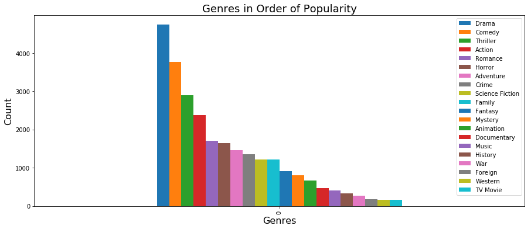

```python
df_just_genres.plot(kind='bar', figsize=(15, 6))
plt.title('Genres in Order of Popularity', fontsize=18)
plt.xlabel('Genres', fontsize=16)
plt.ylabel('Count', fontsize=16);
```

### Next, we will take a more detailed look at which genres were popular year over year.

### Make a new dataframe for only the genres and their release_year

```python
# Get the list of columns for reference
df.columns
```

```
Index(['id', 'imdb_id', 'popularity', 'budget', 'revenue', 'original_title',
       'cast', 'director', 'keywords', 'runtime', 'genres',
       'production_companies', 'release_date', 'vote_count', 'vote_average',
       'release_year', 'budget_adj', 'revenue_adj'],
      dtype='object')
```

### The movie database contains information on movies spanning 56 years (1960 - 2015).

```python
df.release_year.value_counts().count()
```

```
56
```

### Next are some general statistics regarding the release years of each movie in the dataframe.

### This points at for the ~ 11,000 movies, at least half of the movies listed were released in 2006 or later.

```python
df.release_year.describe()
```

```
count    10732.000000
mean      2001.260436
std         12.819831
min       1960.000000
25%       1995.000000
50%       2006.000000
75%       2011.000000
max       2015.000000
Name: release_year, dtype: float64
```

### The new dataframe will focus on the columns for movie titles, genres, and the year the movie was released.

```python
# Filter the original dataset for only movie title, genres, and release_year columns
df_genre_year = df.drop(['id', 'imdb_id', 'popularity', 'budget', 'revenue', 'cast', 'director', 'keywords',
                         'runtime', 'production_companies', 'release_date', 'vote_count', 'vote_average',
                         'budget_adj', 'revenue_adj'], axis=1)
df_genre_year.head()
```

|  | original_title | genres | release_year |
| --- | --- | --- | --- |
| 0 | Jurassic World | Action\|Adventure\|Science Fiction\|Thriller | 2015 |
| 1 | Mad Max: Fury Road | Action\|Adventure\|Science Fiction\|Thriller | 2015 |
| 2 | Insurgent | Adventure\|Science Fiction\|Thriller | 2015 |
| 3 | Star Wars: The Force Awakens | Action\|Adventure\|Science Fiction\|Fantasy | 2015 |
| 4 | Furious 7 | Action\|Crime\|Thriller | 2015 |

### Currently, the genre column consists of strings of multiple genres for per movie. To focus on each individual genre per movie and relate it to it's release year, we will separate out each genre name.

### Next will make an empty dataframe to store genre and matching release year

```python
df_genre_year.genres = df_genre_year.genres.apply(str_to_list)
df_genre_year.head()
```

|  | original_title | genres | release_year |
| --- | --- | --- | --- |
| 0 | Jurassic World | [Action, Adventure, Science Fiction, Thriller] | 2015 |
| 1 | Mad Max: Fury Road | [Action, Adventure, Science Fiction, Thriller] | 2015 |
| 2 | Insurgent | [Adventure, Science Fiction, Thriller] | 2015 |
| 3 | Star Wars: The Force Awakens | [Action, Adventure, Science Fiction, Fantasy] | 2015 |
| 4 | Furious 7 | [Action, Crime, Thriller] | 2015 |

```python
# Make an empty genres and release_year lists
genres = []
release_year = []
```

```python
# Populate the genre_to_year dataframe from the df_genre_year dataframe

for index, row in df_genre_year.iterrows():
    row = row.genres
    year = df_genre_year.release_year[index]  # collect the release_year for this list of genres

    for genre in row:      # add genres and release year to the starting lists
        genres.append(genre)
        release_year.append(year)
```

```python
# Make new dataframe from the genres, release_year lists
genre_to_year = pd.DataFrame({
    'genres': genres,
    'release_year': release_year
})
genre_to_year.head()
```

|  | genres | release_year |
| --- | --- | --- |
| 0 | Action | 2015 |
| 1 | Adventure | 2015 |
| 2 | Science Fiction | 2015 |
| 3 | Thriller | 2015 |
| 4 | Action | 2015 |

### To see better that this a dataframe is using the full list of years (2015 through 1960)

```python
genre_to_year.tail()
```

|  | genres | release_year |
| --- | --- | --- |
| 26753 | Mystery | 1966 |
| 26754 | Comedy | 1966 |
| 26755 | Action | 1966 |
| 26756 | Comedy | 1966 |
| 26757 | Horror | 1966 |

```python
# Sort each genre with each of their release years
genre_to_year.sort_values(['genres', 'release_year']).head()
```

|  | genres | release_year |
| --- | --- | --- |
| 24873 | Action | 1960 |
| 24876 | Action | 1960 |
| 24897 | Action | 1960 |
| 24909 | Action | 1960 |
| 24911 | Action | 1960 |

```python
genre_to_year.shape
```

```
(26758, 2)
```

### Next we will use the crosstab() or cross-tabulation method to compare each genre with their release years.

### Here we can see for each year how many times each genre was referenced. Ultimately, we will determine which genre had the maximum number for each release_year listed in the dataframe. The genre with the most years will be our winner for the most popular genre year over year (yoy).

```python
genre_yoy = pd.crosstab(genre_to_year.release_year, genre_to_year.genres)
genre_yoy
```

| genres release_year | Action | Adventure | Animation | Comedy | Crime | Documentary | Drama | Family | Fantasy | Foreign | History | Horror | Music | Mystery | Romance | Science Fiction | TV Movie | Thriller | War | Western |
| --- | --- | --- | --- | --- | --- | --- | --- | --- | --- | --- | --- | --- | --- | --- | --- | --- | --- | --- | --- | --- |
| 1960 | 8 | 5 | 0 | 8 | 2 | 0 | 13 | 3 | 2 | 1 | 5 | 7 | 1 | 0 | 6 | 3 | 0 | 6 | 2 | 6 |
| 1961 | 7 | 6 | 1 | 10 | 2 | 0 | 16 | 5 | 2 | 1 | 3 | 3 | 2 | 1 | 7 | 4 | 0 | 0 | 2 | 3 |
| 1962 | 8 | 7 | 0 | 5 | 3 | 0 | 21 | 2 | 1 | 1 | 4 | 5 | 1 | 4 | 5 | 2 | 0 | 7 | 3 | 3 |
| 1963 | 4 | 7 | 1 | 13 | 4 | 0 | 13 | 3 | 2 | 2 | 4 | 9 | 0 | 6 | 8 | 2 | 0 | 10 | 1 | 2 |
| 1964 | 5 | 5 | 2 | 16 | 10 | 0 | 20 | 4 | 4 | 1 | 3 | 6 | 5 | 4 | 9 | 4 | 0 | 9 | 3 | 1 |
| 1965 | 9 | 6 | 1 | 7 | 2 | 0 | 20 | 3 | 0 | 1 | 4 | 5 | 2 | 3 | 5 | 2 | 1 | 11 | 8 | 4 |
| 1966 | 14 | 11 | 3 | 16 | 5 | 1 | 16 | 7 | 2 | 2 | 2 | 3 | 0 | 6 | 6 | 6 | 0 | 8 | 4 | 7 |
| 1967 | 7 | 7 | 1 | 17 | 7 | 1 | 16 | 3 | 3 | 0 | 0 | 4 | 4 | 3 | 11 | 4 | 0 | 5 | 1 | 2 |
| 1968 | 6 | 5 | 3 | 9 | 5 | 0 | 19 | 5 | 5 | 0 | 3 | 4 | 3 | 4 | 6 | 4 | 0 | 5 | 4 | 1 |
| 1969 | 10 | 5 | 2 | 11 | 3 | 0 | 13 | 4 | 2 | 0 | 3 | 1 | 2 | 1 | 4 | 3 | 1 | 3 | 3 | 7 |
| 1970 | 11 | 6 | 2 | 12 | 4 | 3 | 19 | 3 | 3 | 1 | 3 | 5 | 4 | 3 | 6 | 3 | 1 | 5 | 5 | 8 |
| 1971 | 11 | 5 | 1 | 9 | 10 | 0 | 30 | 2 | 2 | 0 | 3 | 7 | 1 | 6 | 9 | 6 | 1 | 17 | 4 | 5 |
| 1972 | 10 | 5 | 1 | 13 | 7 | 1 | 16 | 2 | 1 | 0 | 0 | 8 | 2 | 4 | 5 | 4 | 0 | 10 | 0 | 5 |
| 1973 | 15 | 5 | 3 | 8 | 17 | 1 | 31 | 4 | 1 | 0 | 2 | 15 | 1 | 7 | 3 | 6 | 1 | 16 | 0 | 4 |
| 1974 | 14 | 8 | 1 | 12 | 15 | 2 | 21 | 4 | 3 | 0 | 1 | 8 | 1 | 5 | 4 | 5 | 1 | 20 | 1 | 2 |
| 1975 | 10 | 8 | 1 | 12 | 6 | 1 | 17 | 2 | 4 | 0 | 3 | 8 | 3 | 8 | 2 | 11 | 0 | 13 | 2 | 3 |
| 1976 | 13 | 6 | 0 | 12 | 8 | 1 | 22 | 3 | 2 | 1 | 2 | 9 | 3 | 7 | 5 | 5 | 1 | 17 | 2 | 3 |
| 1977 | 14 | 15 | 5 | 10 | 2 | 1 | 23 | 7 | 9 | 0 | 4 | 14 | 3 | 5 | 4 | 11 | 0 | 12 | 4 | 1 |
| 1978 | 15 | 11 | 2 | 14 | 6 | 3 | 29 | 6 | 5 | 1 | 2 | 19 | 3 | 7 | 5 | 16 | 3 | 22 | 4 | 1 |
| 1979 | 8 | 8 | 1 | 19 | 8 | 0 | 30 | 5 | 0 | 0 | 3 | 11 | 4 | 4 | 8 | 10 | 0 | 16 | 3 | 4 |
| 1980 | 27 | 14 | 0 | 25 | 9 | 0 | 32 | 4 | 7 | 2 | 5 | 16 | 4 | 9 | 9 | 11 | 1 | 25 | 2 | 5 |
| 1981 | 17 | 14 | 3 | 20 | 10 | 2 | 32 | 5 | 3 | 0 | 5 | 24 | 3 | 10 | 10 | 10 | 1 | 27 | 2 | 0 |
| 1982 | 17 | 10 | 6 | 28 | 9 | 1 | 33 | 8 | 13 | 2 | 2 | 20 | 6 | 10 | 12 | 13 | 1 | 17 | 2 | 2 |
| 1983 | 21 | 14 | 3 | 28 | 11 | 0 | 35 | 4 | 10 | 1 | 1 | 13 | 5 | 5 | 14 | 16 | 1 | 24 | 1 | 1 |
| 1984 | 33 | 22 | 0 | 38 | 15 | 2 | 40 | 9 | 15 | 0 | 5 | 18 | 11 | 4 | 19 | 27 | 1 | 24 | 3 | 0 |
| 1985 | 28 | 28 | 2 | 51 | 14 | 1 | 39 | 12 | 14 | 0 | 0 | 14 | 2 | 3 | 21 | 17 | 0 | 24 | 2 | 2 |
| 1986 | 30 | 17 | 6 | 49 | 18 | 0 | 51 | 12 | 11 | 0 | 3 | 30 | 6 | 7 | 25 | 21 | 0 | 23 | 4 | 1 |
| 1987 | 29 | 17 | 3 | 57 | 21 | 0 | 52 | 16 | 18 | 0 | 3 | 25 | 4 | 7 | 24 | 18 | 2 | 28 | 6 | 1 |
| 1988 | 31 | 14 | 5 | 69 | 21 | 4 | 53 | 15 | 15 | 1 | 4 | 36 | 7 | 9 | 19 | 18 | 2 | 33 | 6 | 0 |
| 1989 | 38 | 24 | 4 | 63 | 25 | 2 | 54 | 16 | 16 | 2 | 4 | 25 | 3 | 8 | 22 | 21 | 0 | 35 | 4 | 1 |
| 1990 | 39 | 23 | 4 | 48 | 30 | 1 | 60 | 12 | 13 | 1 | 4 | 26 | 2 | 14 | 19 | 18 | 1 | 46 | 2 | 3 |
| 1991 | 39 | 21 | 3 | 60 | 20 | 3 | 63 | 21 | 19 | 3 | 1 | 13 | 7 | 9 | 26 | 13 | 0 | 37 | 2 | 2 |
| 1992 | 34 | 17 | 4 | 54 | 25 | 0 | 65 | 16 | 14 | 3 | 4 | 16 | 6 | 10 | 31 | 16 | 0 | 45 | 1 | 2 |
| 1993 | 53 | 26 | 6 | 72 | 28 | 0 | 90 | 29 | 13 | 5 | 8 | 18 | 6 | 15 | 34 | 18 | 0 | 45 | 6 | 3 |
| 1994 | 61 | 33 | 8 | 88 | 26 | 2 | 83 | 35 | 24 | 3 | 3 | 13 | 3 | 10 | 35 | 20 | 5 | 45 | 3 | 8 |
| 1995 | 47 | 32 | 7 | 63 | 31 | 2 | 93 | 33 | 17 | 2 | 7 | 19 | 0 | 14 | 37 | 18 | 1 | 49 | 5 | 3 |
| 1996 | 42 | 30 | 8 | 91 | 19 | 3 | 104 | 31 | 22 | 2 | 5 | 17 | 4 | 13 | 44 | 24 | 2 | 61 | 3 | 0 |
| 1997 | 59 | 35 | 9 | 76 | 28 | 2 | 83 | 32 | 21 | 3 | 7 | 18 | 4 | 21 | 32 | 29 | 1 | 61 | 1 | 0 |
| 1998 | 43 | 38 | 16 | 84 | 34 | 3 | 108 | 34 | 22 | 4 | 7 | 23 | 12 | 18 | 41 | 26 | 3 | 53 | 3 | 1 |
| 1999 | 38 | 20 | 13 | 100 | 29 | 5 | 113 | 29 | 23 | 6 | 7 | 26 | 5 | 24 | 42 | 29 | 6 | 53 | 3 | 3 |
| 2000 | 47 | 28 | 25 | 97 | 31 | 3 | 100 | 34 | 21 | 4 | 4 | 21 | 10 | 14 | 47 | 24 | 1 | 63 | 5 | 2 |
| 2001 | 61 | 40 | 18 | 101 | 39 | 5 | 100 | 31 | 25 | 4 | 12 | 23 | 6 | 22 | 53 | 25 | 10 | 66 | 12 | 2 |
| 2002 | 72 | 45 | 21 | 104 | 41 | 8 | 129 | 39 | 20 | 11 | 8 | 30 | 3 | 28 | 48 | 28 | 3 | 83 | 7 | 1 |
| 2003 | 73 | 41 | 29 | 111 | 46 | 11 | 110 | 44 | 27 | 5 | 9 | 24 | 11 | 19 | 49 | 41 | 3 | 73 | 8 | 4 |
| 2004 | 75 | 49 | 23 | 125 | 32 | 12 | 141 | 40 | 19 | 7 | 7 | 29 | 13 | 27 | 63 | 34 | 6 | 74 | 8 | 7 |
| 2005 | 70 | 53 | 24 | 143 | 45 | 17 | 182 | 56 | 34 | 10 | 10 | 56 | 13 | 29 | 62 | 25 | 3 | 92 | 5 | 2 |
| 2006 | 79 | 55 | 35 | 155 | 53 | 16 | 196 | 63 | 34 | 10 | 12 | 56 | 11 | 30 | 70 | 30 | 8 | 114 | 7 | 1 |
| 2007 | 94 | 60 | 31 | 151 | 65 | 16 | 197 | 45 | 47 | 16 | 12 | 78 | 15 | 33 | 74 | 38 | 5 | 123 | 6 | 5 |
| 2008 | 98 | 63 | 32 | 165 | 62 | 24 | 232 | 55 | 43 | 17 | 23 | 76 | 18 | 29 | 83 | 52 | 5 | 127 | 17 | 2 |
| 2009 | 108 | 71 | 47 | 198 | 52 | 23 | 222 | 58 | 48 | 16 | 16 | 90 | 17 | 50 | 83 | 70 | 8 | 157 | 12 | 0 |
| 2010 | 107 | 58 | 47 | 168 | 50 | 30 | 209 | 54 | 42 | 13 | 14 | 78 | 8 | 32 | 84 | 46 | 7 | 134 | 7 | 6 |
| 2011 | 115 | 61 | 42 | 171 | 48 | 45 | 213 | 70 | 45 | 13 | 8 | 78 | 17 | 38 | 75 | 56 | 10 | 146 | 9 | 3 |
| 2012 | 99 | 50 | 35 | 173 | 54 | 45 | 231 | 41 | 33 | 6 | 12 | 104 | 22 | 33 | 79 | 54 | 14 | 160 | 10 | 4 |
| 2013 | 119 | 65 | 42 | 173 | 71 | 58 | 253 | 47 | 38 | 0 | 14 | 102 | 30 | 38 | 65 | 60 | 9 | 175 | 7 | 3 |
| 2014 | 129 | 67 | 35 | 183 | 65 | 58 | 284 | 43 | 36 | 0 | 15 | 105 | 27 | 36 | 83 | 61 | 12 | 178 | 22 | 6 |
| 2015 | 106 | 69 | 37 | 160 | 51 | 51 | 260 | 44 | 33 | 0 | 15 | 125 | 33 | 42 | 56 | 84 | 20 | 171 | 9 | 6 |

```python
# Size for the cross-tabulation matrix
genre_yoy.shape
```

```
(56, 20)
```

### The following code wil review each row and determine which genre was most reference for that release year. The count for the winning genre for each year will be stored in a dictionary.

```python
max_genre_per_year = {}  # dictionary - genre as key, and times it was most popular for that release year as value
for index, row in genre_yoy.iterrows():
    most_genre = row.idxmax()  # column name for the maximum value in the row
    max_genre_per_year[most_genre] = max_genre_per_year.get(most_genre, 0) + 1

max_genre_per_year
```

```
{'Drama': 46, 'Comedy': 10}
```

### Drama is the most popular genre year over year.

#### --------------------------------------------------------------------------------------------------------------------------------------------------------------------------

## Question #2 - Which directors are associated with movies that have high revenues?

### To explore this question, let's start from the original dataframe (df).

```python
# Maximum revenue
df.revenue.max()
```

```
2781505847
```

```python
# The movie with the highest revenue
df[df.revenue == df.revenue.max()]
```

|  | id | imdb_id | popularity | budget | revenue | original_title | cast | director | keywords | runtime | genres | production_companies | release_date | vote_count | vote_average | release_year | budget_adj | revenue_adj |
| --- | --- | --- | --- | --- | --- | --- | --- | --- | --- | --- | --- | --- | --- | --- | --- | --- | --- | --- |
| 1386 | 19995 | tt0499549 | 9.432768 | 237000000 | 2781505847 | Avatar | Sam Worthington\|Zoe Saldana\|Sigourney Weaver\|S... | James Cameron | culture clash\|future\|space war\|space colony\|so... | 162 | Action\|Adventure\|Fantasy\|Science Fiction | Ingenious Film Partners\|Twentieth Century Fox ... | 12/10/09 | 8458 | 7.1 | 2009 | 2.408869e+08 | 2.827124e+09 |

### Avatar, directed by James Cameron, has the listed highest revenue (~2.8 Billion).

### Check the mean and median of the listed movie revenues.

```python
# Average revenue, Median revenue
df.revenue.mean(), df.revenue.median()
```

```
(40316220.714405514, 0.0)
```

### The mean revenue is ~40.3 Million; however, note the median is 0.

### To possibly answer why, check how many values in the revenue column are of value 0 and the overall size of our dataframe df.

```python
revenue_0_count = df.query('revenue == 0.0').count().revenue
revenue_0_count
```

```
5888
```

```python
# Size of dataframe
df.shape
```

```
(10732, 18)
```

### Movies listing a revenue of 0 are over half of all revenues listed. Since a focus of this analysis is high revenue , the mean value will be used instead and no change will be made to the revenues of 0 value.

### Next, gather list of movies with revenues greater than or equal to the average revenue.

```python
# Find all with above average revenue
high_revenue = df.query('revenue >= revenue.mean()')
```

### Next here are some further statistics on the movies with high revenues.

```python
high_revenue.describe()
```

|  | id | popularity | budget | revenue | runtime | vote_count | vote_average | release_year | budget_adj | revenue_adj |
| --- | --- | --- | --- | --- | --- | --- | --- | --- | --- | --- |
| count | 2156.000000 | 2156.000000 | 2.156000e+03 | 2.156000e+03 | 2156.000000 | 2156.000000 | 2156.000000 | 2156.000000 | 2.156000e+03 | 2.156000e+03 |
| mean | 37165.886364 | 1.627447 | 5.222593e+07 | 1.847000e+08 | 112.685529 | 818.325603 | 6.288080 | 2001.890538 | 6.022298e+07 | 2.330761e+08 |
| std | 66313.222546 | 1.787504 | 4.866996e+07 | 2.061715e+08 | 24.000781 | 1062.532791 | 0.733173 | 10.676995 | 5.044509e+07 | 2.510935e+08 |
| min | 11.000000 | 0.010335 | 0.000000e+00 | 4.034619e+07 | 44.000000 | 10.000000 | 3.400000 | 1960.000000 | 0.000000e+00 | 3.719001e+07 |
| 25% | 2317.500000 | 0.740467 | 1.800000e+07 | 6.719821e+07 | 98.000000 | 193.000000 | 5.800000 | 1996.000000 | 2.423495e+07 | 8.435076e+07 |
| 50% | 10029.000000 | 1.165161 | 3.950000e+07 | 1.137862e+08 | 109.000000 | 423.000000 | 6.300000 | 2004.000000 | 4.661412e+07 | 1.465554e+08 |
| 75% | 36989.750000 | 1.890647 | 7.000000e+07 | 2.143081e+08 | 123.000000 | 976.750000 | 6.800000 | 2010.000000 | 8.342099e+07 | 2.793391e+08 |
| max | 417859.000000 | 32.985763 | 3.800000e+08 | 2.781506e+09 | 705.000000 | 9767.000000 | 8.300000 | 2015.000000 | 3.683713e+08 | 2.827124e+09 |

### Some general statistics:

> - 2156 movies have above average revenue ( >= ~40.3 Million )
> - Half made more than ~114 Million
> - Highest revenue was ~2.8 Billion (Avatar)

### Overall number of directors in this dataframe.

```python
df.director.value_counts().sum()
```

```
10732
```

### The top 10 directors by order of number of movies with higher than average revenue (~40M).

```python
top_10_directors = high_revenue.director.value_counts().head(10)
top_10_directors
```

```
Steven Spielberg    25
Clint Eastwood      20
Ridley Scott        17
Ron Howard          16
Tim Burton          14
Robert Zemeckis     14
Michael Bay         11
Joel Schumacher     11
Tony Scott          11
Ivan Reitman        10
Name: director, dtype: int64
```

### The following is a simple bar chart for our top 10 directors for the movies with above average revenues (~40M).

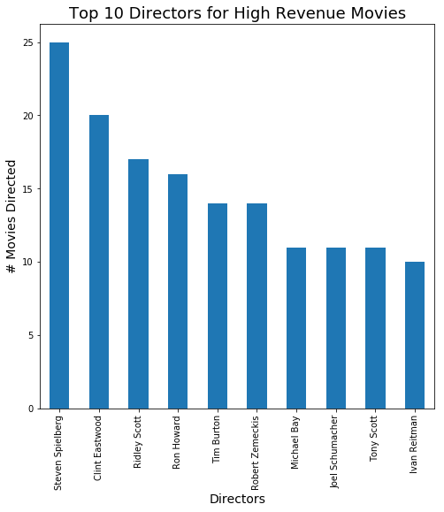

```python
high_revenue.director.value_counts().head(10).plot(kind='bar', figsize=(8, 8))
plt.title('Top 10 Directors for High Revenue Movies', fontsize=18)
plt.xlabel('Directors', fontsize=14)
plt.ylabel('# Movies Directed', fontsize=14);
```

### The following will find the top directors determined by their overall movie revenues.

```python
# Show first few rows of this dataframe, but only the revenue, title, and director columns
high_revenue_directors = high_revenue.iloc[:, np.r_[4:6, 7:8]]
high_revenue_directors.head()
```

|  | revenue | original_title | director |
| --- | --- | --- | --- |
| 0 | 1513528810 | Jurassic World | Colin Trevorrow |
| 1 | 378436354 | Mad Max: Fury Road | George Miller |
| 2 | 295238201 | Insurgent | Robert Schwentke |
| 3 | 2068178225 | Star Wars: The Force Awakens | J.J. Abrams |
| 4 | 1506249360 | Furious 7 | James Wan |

```python
# Size of dataframe
high_revenue_directors.shape
```

```
(2156, 3)
```

### Next shows the total revenues for the top 25 directors.

```python
high_rev_director = high_revenue_directors.groupby('director').revenue.sum().sort_values(ascending=False).head(25)
high_rev_director.head(25)
```

```
director
Steven Spielberg      8974008030
Peter Jackson         6490593685
James Cameron         5824853992
Michael Bay           4917208171
David Yates           4154295625
Christopher Nolan     4127825406
Robert Zemeckis       3857975548
Chris Columbus        3763621616
Tim Burton            3630643656
J.J. Abrams           3579169916
Ridley Scott          3573955750
Gore Verbinski        3536296904
Ron Howard            3426843181
Roland Emmerich       3393137900
George Lucas          3314113893
Francis Lawrence      3179979588
Sam Raimi             3127936214
Joss Whedon           2924593677
Sam Mendes            2698649392
Clint Eastwood        2690551825
Carlos Saldanha       2532451792
M. Night Shyamalan    2452354930
Barry Sonnenfeld      2320392063
Shawn Levy            2218587063
David Fincher         2139346325
Name: revenue, dtype: int64
```

### Next we will build a plot.

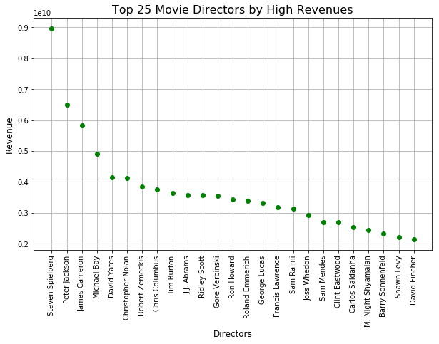

```python
directors = high_rev_director.index   # list of top 25 director names
high_rev = high_rev_director.values   # list of revenue totals per director
plt.title('Top 25 Movie Directors by High Revenues', fontsize=16)
plt.xticks(rotation='vertical')
plt.xlabel('Directors', fontsize=12)
plt.ylabel('Revenue', fontsize=12)
plt.plot(directors, high_rev, 'go')   # plot points as green 'o'
plt.grid()
fig = plt.gcf()
fig.set_size_inches(10, 6);
```

#### --------------------------------------------------------------------------------------------------------------------------------------------------------------------------

## Question #3 - Who are the most featured actors?

```python
# Determine the index number for the actors (cast), movie title columns, and revenue.
df.columns
```

```
Index(['id', 'imdb_id', 'popularity', 'budget', 'revenue', 'original_title',
       'cast', 'director', 'keywords', 'runtime', 'genres',
       'production_companies', 'release_date', 'vote_count', 'vote_average',
       'release_year', 'budget_adj', 'revenue_adj'],
      dtype='object')
```

```python
# Verify column names
df.columns[6], df.columns[5], df.columns[4]
```

```
('cast', 'original_title', 'revenue')
```

```python
# Select the cast, movie title, and revenue columns to use for this analysis
df_actors = df.iloc[:, 4:7].copy()
df_actors.head()
```

|  | revenue | original_title | cast |
| --- | --- | --- | --- |
| 0 | 1513528810 | Jurassic World | Chris Pratt\|Bryce Dallas Howard\|Irrfan Khan\|Vi... |
| 1 | 378436354 | Mad Max: Fury Road | Tom Hardy\|Charlize Theron\|Hugh Keays-Byrne\|Nic... |
| 2 | 295238201 | Insurgent | Shailene Woodley\|Theo James\|Kate Winslet\|Ansel... |
| 3 | 2068178225 | Star Wars: The Force Awakens | Harrison Ford\|Mark Hamill\|Carrie Fisher\|Adam D... |
| 4 | 1506249360 | Furious 7 | Vin Diesel\|Paul Walker\|Jason Statham\|Michelle ... |

```python
# Size of dataframe
df_actors.shape
```

```
(10732, 3)
```

### Convert each movies cast string to a list of strings for each actor's name

```python
df_actors.cast = df_actors.cast.apply(str_to_list)
df_actors.head()
```

|  | revenue | original_title | cast |
| --- | --- | --- | --- |
| 0 | 1513528810 | Jurassic World | [Chris Pratt, Bryce Dallas Howard, Irrfan Khan... |
| 1 | 378436354 | Mad Max: Fury Road | [Tom Hardy, Charlize Theron, Hugh Keays-Byrne,... |
| 2 | 295238201 | Insurgent | [Shailene Woodley, Theo James, Kate Winslet, A... |
| 3 | 2068178225 | Star Wars: The Force Awakens | [Harrison Ford, Mark Hamill, Carrie Fisher, Ad... |
| 4 | 1506249360 | Furious 7 | [Vin Diesel, Paul Walker, Jason Statham, Miche... |

### Now our string of actor names have been converted to a list of strings for each row (movie) for easier analysis.

### As before, we will create a new dataframe to collect each actor and the revenue for each movie they starred in.

```python
# make an empty actors and movie titles list
actor_list = []
movie_list = []
revenue_list = []
```

```python
for index, row in df_actors.iterrows():
    row = row.cast
    movie_title, movie_revenue = df.original_title[index], df.revenue[index]  # collect associated title and revenue

    for actor in row:
        actor_list.append(actor)
        movie_list.append(movie_title)
        revenue_list.append(movie_revenue)
```

```python
# Make new dataframe from the actor, movie title lists
actor_to_movie = pd.DataFrame({
    'actors': actor_list,
    'movie_title': movie_list,
    'revenue': revenue_list
})
actor_to_movie.head(10)
```

|  | actors | movie_title | revenue |
| --- | --- | --- | --- |
| 0 | Chris Pratt | Jurassic World | 1513528810 |
| 1 | Bryce Dallas Howard | Jurassic World | 1513528810 |
| 2 | Irrfan Khan | Jurassic World | 1513528810 |
| 3 | Vincent D'Onofrio | Jurassic World | 1513528810 |
| 4 | Nick Robinson | Jurassic World | 1513528810 |
| 5 | Tom Hardy | Mad Max: Fury Road | 378436354 |
| 6 | Charlize Theron | Mad Max: Fury Road | 378436354 |
| 7 | Hugh Keays-Byrne | Mad Max: Fury Road | 378436354 |
| 8 | Nicholas Hoult | Mad Max: Fury Road | 378436354 |
| 9 | Josh Helman | Mad Max: Fury Road | 378436354 |

```python
# Size of actor_to_movie dataframe
actor_to_movie.shape
```

```
(52339, 3)
```

### There are over 52K actor references in this dataframe. However, the following shows a much smaller number of unique actors are listed.

```python
# Total number of actors listed
actor_to_movie.actors.value_counts().count()
```

```
18930
```

### Next we will collect the top 500 most featured actors. Since in order to find the most featured actors, we needed to count the number of times each actor was listed. Pandas returns the actor name and an integer for each actor.

### However, we only want the actors names.

### To achieve this, the returned Series of most_active_actors is converted to a string. This string will require some reformatting to parse out the actor names, which will then be converted to a list of strings. This will be easier to use for further analysis.

```python
# Top 500 most working actors listed
most_active_actors = actor_to_movie.actors.value_counts().head(500)
actors_top_500 = most_active_actors.to_string()
actors_top_500[:100]  # View of the string format
```

```
'Robert De Niro            72\nSamuel L. Jackson         71\nBruce Willis              62\nNicolas Cage '
```

### For reference, here is the list of actors and their associated movie counts from this dataframe.

```python
actors_top_500
```

[output not shown]

### Next we will format the actors_top_500 to a list of actor names .

```python
actors_500 = []
temp = actors_top_500.split('\n')

for name in temp:
    name_temp = ''
    for char in name:
        if char.isdigit()== False:  # only parse out the name characters and whitespace
            name_temp += char   # save to a temporary string
        else: continue

    actor = name_temp.strip()  # strip the trailing whitespace
    actors_500.append(actor)

actors_500
```

```
['Robert De Niro',
 'Samuel L. Jackson',
 'Bruce Willis',
 'Nicolas Cage',
 'Michael Caine',
 'Robin Williams',
 'John Cusack',
 'John Goodman',
 'Morgan Freeman',
 'Liam Neeson',
 'Susan Sarandon',
 'Julianne Moore',
 'Alec Baldwin',
 'Christopher Walken',
 'Gene Hackman',
 'Johnny Depp',
 'Tom Hanks',
 'Dennis Quaid',
 'Willem Dafoe',
 'Ed Harris',
 'Donald Sutherland',
 'Sylvester Stallone',
 'Meryl Streep',
 'Clint Eastwood',
 'Ewan McGregor',
 'Antonio Banderas',
 'Woody Harrelson',
 'Keanu Reeves',
 'Eddie Murphy',
 'Anthony Hopkins',
 'Nicole Kidman',
 'Harrison Ford',
 'Danny Glover',
 'Al Pacino',
 'John Travolta',
 'Dustin Hoffman',
 'James Franco',
 'Steve Buscemi',
 'Robert Downey Jr.',
 'Ray Liotta',
```

[output cut: 445 more lines]

```
 'Matthew Modine',
 'Oliver Reed',
 'Tom Selleck',
 'Jane Fonda',
 'Djimon Hounsou',
 'Danny Huston',
 'Kevin Sorbo',
 'Ben Foster',
 'David Arquette',
 'Scott Speedman',
 'Sienna Miller',
 'Michael PeÃ±a',
 'William Shatner',
 'David Koechner',
 'Mandy Moore']
```

### Next we will separate out the female actors in order to do some further comparision among the top 500 actors.

### This was a manual process of separating out the female names to a separate list.

```python
female_actors = ['Susan Sarandon', 'Julianne Moore', 'Meryl Streep', 'Cameron Diaz', 'Winona Ryder', 'Julia Roberts',
                 'Sandra Bullock', 'Drew Barrymore', 'Michelle Pfeiffer', 'Naomi Watts', 'Rosario Dawson',
                 'Scarlett Johansson', 'Sigourney Weaver', 'Cate Blanchett', 'Angelina Jolie', 'Gwyneth Paltrow',
                 'Charlize Theron', 'Kate Winslet', 'Uma Thurman', 'Helen Mirren', 'Reese Witherspoon',
                 'Catherine Keener', 'Helena Bonham Carter', 'Diane Keaton', 'Demi Moore', 'Joan Cusack',
                 'Toni Collette', 'Christina Ricci', 'Kate Beckinsale', 'Jennifer Connelly', 'Kirsten Dunst',
                 'Daryl Hannah', 'Rachel Weisz', 'Marisa Tomei', 'Jennifer Aniston', 'Salma Hayek', 'Whoopi Goldberg',
                 'Elizabeth Banks', 'Anjelica Huston', 'Kristen Stewart', 'Meg Ryan', 'Heather Graham', 'Emma Thompson',
                 'Jodie Foster', 'Diane Lane', 'Jamie Lee Curtis', 'Maria Bello', 'Kim Basinger', 'Keira Knightley',
                 'Sharon Stone', 'Judi Dench', 'Jennifer Jason Leigh', 'Kathy Bates', 'Dakota Fanning', 'Jennifer Lopez',
                 'Halle Berry', 'Jessica Biel', 'Anne Hathaway', 'Glenn Close', 'Juliette Lewis', 'Angela Bassett',
                 'Evan Rachel Wood', 'Frances McDormand', 'Kate Hudson', 'Amy Adams', 'Milla Jovovich', 'Rachel McAdams',
                 'Carla Gugino', 'Lucy Liu', 'Miranda Richardson', 'Eva Mendes', 'Amanda Peet', 'Mary Steenburgen',
                 'Carrie-Anne Moss', 'Jessica Alba', 'Mia Farrow', 'Natalie Portman', 'Zooey Deschanel',
                 'Shirley MacLaine', 'Selma Blair', 'Maggie Smith', 'Virginia Madsen', 'Sally Field',
                 'Charlotte Rampling', 'Faye Dunaway', 'Catherine Zeta-Jones', 'Olivia Wilde', 'Emily Blunt',
                 'Queen Latifah', 'Jesse Eisenberg', 'Mimi Rogers', 'Patricia Clarkson', 'Laura Linney', 'Laura Dern',
                 'PenÃ©lope Cruz', 'Annette Bening', 'Brittany Murphy', 'Marcia Gay Harden', "Catherine O'Hara",
                 'Grey Griffin', 'Michelle Williams', 'Rose Byrne', 'Amanda Seyfried', 'Hilary Swank', 'Mila Kunis',
                 'Kristen Wiig', 'Jessica Chastain', 'Amy Smart', 'Anna Faris', 'Barbara Hershey', 'Zoe Saldana',
                 'Emily Mortimer', 'Kate Bosworth', 'Lindsay Lohan', 'Viola Davis', 'Katherine Heigl', 'Emily Watson',
                 'Liv Tyler', 'Juno Temple', 'Kristen Bell', 'Kristin Scott Thomas', 'Dianne Wiest', 'Katie Holmes',
                 'Radha Mitchell', 'Helen Hunt', 'Holly Hunter', 'ChloÃ« Grace Moretz', 'Christina Applegate',
                 'Jessica Lange', 'Melanie Griffith', 'Kathleen Turner', 'Anna Kendrick', 'Tilda Swinton', 'Claire Danes',
                 'Abigail Breslin', 'Emma Roberts', 'Juliette Binoche', 'Amber Heard', 'Famke Janssen',
                 'Sarah Jessica Parker', 'Jennifer Love Hewitt', 'Kelly Preston', 'Kelly Sheridan', 'RenÃ©e Zellweger',
                 'Julia Stiles', 'Michelle Rodriguez', 'Ellen Barkin', 'Vanessa Redgrave', 'Emile Hirsch',
                 'Elisabeth Shue', 'Jennifer Garner', 'Lena Headey', 'Michelle Monaghan', 'Ellen Burstyn', 'Ashley Judd',
                 'Anne Heche', 'Julie Christie', 'Mandy Moore', 'Vera Farmiga', 'Mary-Louise Parker']
```

```python
# Number of female actors in top 500 list
len(female_actors)
```

```
160
```

### Collect the movies featuring the top 500 most active/featured actors.

```python
df_actor_revenue = actor_to_movie.query('actors in @actors_500').copy()
df_actor_revenue.head()
```

|  | actors | movie_title | revenue |
| --- | --- | --- | --- |
| 3 | Vincent D'Onofrio | Jurassic World | 1513528810 |
| 5 | Tom Hardy | Mad Max: Fury Road | 378436354 |
| 6 | Charlize Theron | Mad Max: Fury Road | 378436354 |
| 12 | Kate Winslet | Insurgent | 295238201 |
| 15 | Harrison Ford | Star Wars: The Force Awakens | 2068178225 |

```python
# Size of dataframe for list of movies listing the top 500 actors and the movie revenues.
df_actor_revenue.shape
```

```
(13021, 3)
```

### We will add a column with references the actor's gender for that row of data. This will help in plotting the visualization of male vs female top 500 most featured actors.

### We will first list all genders as male in order to quickly populate a Series to later add to our dataframe.

```python
# Add new column for actor gender
arr = np.repeat('male', len(df_actor_revenue))
gender = pd.Series(arr, name='gender')
```

```python
# Size of Series
gender.shape[0]
```

```
13021
```

### Next we will add this gender column to the dataframe and combine to make a new dataframe.

```python
# Add the gender Series to the df_actor_revenue DataFrame to make a NEW DataFrame
df_actors_rev = pd.concat([df_actor_revenue, gender], axis=1).copy()
df_actors_rev.head()
```

|  | actors | movie_title | revenue | gender |
| --- | --- | --- | --- | --- |
| 0 | NaN | NaN | NaN | male |
| 1 | NaN | NaN | NaN | male |
| 2 | NaN | NaN | NaN | male |
| 3 | Vincent D'Onofrio | Jurassic World | 1.513529e+09 | male |
| 4 | NaN | NaN | NaN | male |

### There are now missing values concat() generates a new dataframe and fills in missing index numbers.

### Next, the rows with missing values will be dropped.

```python
df.describe()
```

|  | id | popularity | budget | revenue | runtime | vote_count | vote_average | release_year | budget_adj | revenue_adj |
| --- | --- | --- | --- | --- | --- | --- | --- | --- | --- | --- |
| count | 10732.000000 | 10732.000000 | 1.073200e+04 | 1.073200e+04 | 10732.000000 | 10732.000000 | 10732.000000 | 10732.000000 | 1.073200e+04 | 1.073200e+04 |
| mean | 65199.598025 | 0.652609 | 1.480506e+07 | 4.031622e+07 | 102.467853 | 219.802739 | 5.964620 | 2001.260436 | 1.776644e+07 | 5.200147e+07 |
| std | 91466.515616 | 1.004757 | 3.106345e+07 | 1.176476e+08 | 30.492619 | 578.789325 | 0.930286 | 12.819831 | 3.446490e+07 | 1.454192e+08 |
| min | 5.000000 | 0.000188 | 0.000000e+00 | 0.000000e+00 | 0.000000 | 10.000000 | 1.500000 | 1960.000000 | 0.000000e+00 | 0.000000e+00 |
| 25% | 10547.750000 | 0.210766 | 0.000000e+00 | 0.000000e+00 | 90.000000 | 17.000000 | 5.400000 | 1995.000000 | 0.000000e+00 | 0.000000e+00 |
| 50% | 20331.000000 | 0.387136 | 0.000000e+00 | 0.000000e+00 | 99.000000 | 39.000000 | 6.000000 | 2006.000000 | 0.000000e+00 | 0.000000e+00 |
| 75% | 73943.750000 | 0.720621 | 1.600000e+07 | 2.500000e+07 | 112.000000 | 148.000000 | 6.600000 | 2011.000000 | 2.111556e+07 | 3.470526e+07 |
| max | 417859.000000 | 32.985763 | 4.250000e+08 | 2.781506e+09 | 900.000000 | 9767.000000 | 9.200000 | 2015.000000 | 4.250000e+08 | 2.827124e+09 |

```python
# Drop NaNs
df_actors_rev.dropna(inplace=True)
df_actors_rev.head()
```

|  | actors | movie_title | revenue | gender |
| --- | --- | --- | --- | --- |
| 3 | Vincent D'Onofrio | Jurassic World | 1.513529e+09 | male |
| 5 | Tom Hardy | Mad Max: Fury Road | 3.784364e+08 | male |
| 6 | Charlize Theron | Mad Max: Fury Road | 3.784364e+08 | male |
| 12 | Kate Winslet | Insurgent | 2.952382e+08 | male |
| 15 | Harrison Ford | Star Wars: The Force Awakens | 2.068178e+09 | male |

### Next we will correct the gender for the female actors.

### We will review each row and compare to the previous list of female_actors in order to update the gender column to have the correct gender.

```python
# Correct the gender for the female actors

for index, row in df_actors_rev.iterrows():
    if row.actors in female_actors:
        df_actors_rev.loc[index, 'gender'] = 'female'
```

```python
df_actors_rev.head()
```

|  | actors | movie_title | revenue | gender |
| --- | --- | --- | --- | --- |
| 3 | Vincent D'Onofrio | Jurassic World | 1.513529e+09 | male |
| 5 | Tom Hardy | Mad Max: Fury Road | 3.784364e+08 | male |
| 6 | Charlize Theron | Mad Max: Fury Road | 3.784364e+08 | female |
| 12 | Kate Winslet | Insurgent | 2.952382e+08 | female |
| 15 | Harrison Ford | Star Wars: The Force Awakens | 2.068178e+09 | male |

### Build a visual for the top movies featuring the top 500 most active actors (male/female).

```python
# Collect rows for male and female actors
male_actors_500 = df_actors_rev.gender == 'male'
female_actors_500 = df_actors_rev.gender == 'female'
male_actors_500.head()
```

```
3      True
5      True
6     False
12    False
15     True
Name: gender, dtype: bool
```

### Next we have the sums for each of the number of male actors and female actors.

```python
male_actors_500.sum(), female_actors_500.sum()
```

```
(2097, 941)
```

### The following plots the male vs female actors.

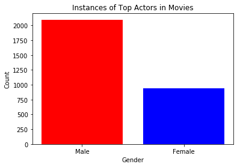

```python
actors = ['male', 'female']
counts = [male_actors_500.sum(), female_actors_500.sum()]
labels = ['Male', 'Female']
plt.bar(actors, counts, tick_label = labels, color = ['r', 'b'])
plt.title('Instances of Top Actors in Movies')
plt.xlabel('Gender')
plt.ylabel('Count');
```

### For the top 500 of the most active actors, ~31% were female.

### The following visualizes the top 20 highest revenue totals and the associated actor.

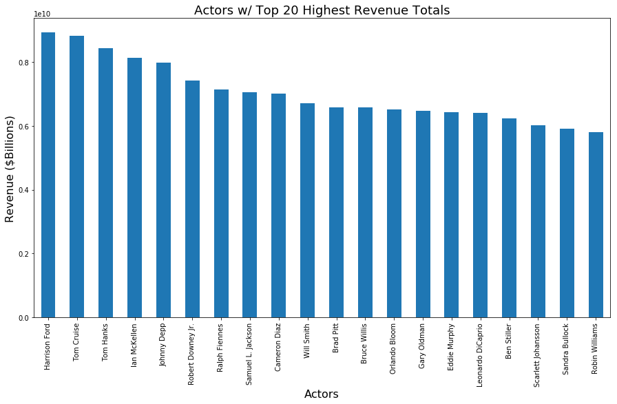

```python
df_actor_revenue.groupby('actors').revenue.sum().sort_values(ascending=False).head(20).plot(kind='bar', figsize=(15, 8))
plt.title('Actors w/ Top 20 Highest Revenue Totals', fontsize=18)
plt.xlabel('Actors', fontsize=16)
plt.ylabel('Revenue ($Billions)', fontsize=16);
```

# Conclusions

##### Analysis of The Movie Database (TMDb) have resulted in the following findings:

> This investigation focused on the most detailed attributes available in the dataset - actors, directors, and genres that could still gleam potentially interesting information. Note: No other sources were used to verify or suppliment the data from the TMDb dataset.

> There were some limitations on the scope of this analysis during the exploration of the dataset. This included missing actual revenues values, and missing production company references. Production company information was not included among the detailed attributes since there was too much missing to deem it useful for comparison. Overall, half of the information per movie was for those released between 2006 and 2015.